# Linear Regression Models: Choosing a Model

## Multiple Linear Regression

- Simple linear regression model can be extended in many ways…
- Can include more *explanatory variables* and/or *higher order terms*

Ex:

\[Y_i = \beta_0 + \beta_1x_{1i} + \beta_2x_{2i} + \beta_3x_{1i}x_{2i}+E_i\]

- Still use `lm()`
  - add "main effect" terms with `+ name`
  - interactions with `+ name1:name2`
  - all possible combinations with `+ name1*name2`
- Still fit by minimizing sum of squared errors

## Multiple Linear Regression

- How to choose between competing models?
- Consider data on voting preferences by county
  - Use pct with college degree & population change in county to predict county level income

```r
voting <- tbl_df(read.csv("../datasets/counties.csv", header = TRUE))
subVoting <- voting %>% select(college, pop.change, income)
subVoting
```

```
## # A tibble: 3,141 x 3
##   college pop.change income
##     <dbl>      <dbl>  <int>
## 1   14.5       11.9   32240
## 2   16.8       35.4   30199
## 3   11.8        2     23838
## 4    4.70       9.20  23714
## 5    7         10.6   26323
## # ... with 3,136 more rows
```

## Including a Categorical Predictor

- May want fits that differ by the level of a variable
- Here a common slope is assumed
- R uses the first level of the categorical variable as a reference level

```r
regionFit <- lm(income ~ college + region, data = voting)
regionFit
```

```
##
## Call:
## lm(formula = income ~ college + region, data = voting)
##
## Coefficients:
##     (Intercept)          college  regionNortheast      regionSouth
##         19584.1            718.6           3100.9          -1801.1
##      regionWest
##         -1529.4
```

## Including a Categorical Predictor

- Perhaps a different slope and different intercept for each group
- Same idea, college coefficient represents slope for Midwest

```r
fullRegionFit <- lm(income ~ college*region, data = voting)
fullRegionFit
```

```
##
## Call:
## lm(formula = income ~ college * region, data = voting)
##
## Coefficients:
##             (Intercept)                  college          regionNortheast
##                20566.12                   642.18                 -1864.03
##             regionSouth               regionWest  college:regionNortheast
##                -3164.12                  -903.73                   289.96
##     college:regionSouth       college:regionWest
##                  107.84                   -18.18
```

## Common Slope vs Different Slopes

- Can choose based on fit criteria
- Some commonly used fit statistics
  - Adjusted R-squared, AIC, AICc, BIC

```r
compareFitStats <- function(fit1, fit2){
    require(MuMIn)
    fitStats <- data.frame(fitStat = c("Adj R Square", "AIC", "AICc", "BIC"),
        col1 = round(c(summary(fit1)$adj.r.squared, AIC(fit1),
                                    MuMIn::AICc(fit1), BIC(fit1)), 3),
            col2 = round(c(summary(fit2)$adj.r.squared, AIC(fit2),
                                    MuMIn::AICc(fit2), BIC(fit2)), 3))
    #put names on returned df
    calls <- as.list(match.call())
    calls[[1]] <- NULL
    names(fitStats)[2:3] <- unlist(calls)
    fitStats
}
```

## Common Slope vs Different Slopes

- For Adjusted R Square, larger is better
- For AIC, AICc, and BIC, smaller is better

```r
compareFitStats(regionFit, fullRegionFit)
```

```
##        fitStat regionFit fullRegionFit
## 1 Adj R Square     0.511         0.516
## 2          AIC 62440.595     62406.807
## 3         AICc 62440.622     62406.865
## 4          BIC 62476.909     62461.278
```

- Each of these take into account model fit and then penalize for model complexity

## Model Selection

- Instead of fit criteria, ideally we would minimize *prediction error* (MSE usually used)

\[MSE = \frac{1}{n}\sum_{i=1}^{n}(y_i-\hat{y}_i)^2\]

- Note: this is the same equation used to find the \(\beta\)'s! (could call it training MSE)
- *prediction error* should be examined over data **not** used in the fitting of the model
- More complex models can lower training MSE but we really want to be able to predict new observations, not the ones we have

## Complexity vs Training Error

- As the training MSE decreases with a more complex model, the corresponding test MSE goes up
- There is a bias/variance trade-off

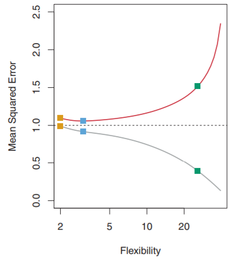

## Model Selection

- If you have a lot of data, you can split it into a training and test set
- Process:
  - Split data randomly into training and test sets (80/20)
  - Fit competing models on the training set
  - Predict for the values in the test set
  - Compute MSE using the predicted values from the test set
- Alternatively, use cross-validation if you don't have a huge amount of data
- Should also look at residuals plots to check for poor fit

## Comparison of Voting Data Models

- Split into training and test sets

```r
#for reproducability
set.seed(111)

#indices to split on
train <- sample(1:nrow(voting), size = nrow(voting)*0.8)
test <- dplyr::setdiff(1:nrow(voting), train)

#subset
voteTrain <- voting[train, ]
voteTest <- voting[test, ]
```

## Comparison of Voting Data Models

- Fit competing models

```r
slrFit <- lm(income ~ college, data = voteTrain)
mlrFit <- lm(income ~ college + pop.change, data = voteTrain)
glmFit <- lm(income ~ college*region, data = voteTrain)
glm2Fit <- lm(income ~ pop.change*region, data = voteTrain)
glm3Fit <- lm(income ~ college*region*pop.change, data = voteTrain)
glm4Fit <- lm(income ~ pop.change + college + pop.change:college +
                        I(pop.change^2) + I(college^2), data = voteTrain)
glm5Fit <- lm(income ~ pop.change*region*college +
                        I(pop.change^2) + I(college^2), data = voteTrain)
```

## Comparison of Voting Data Models

- Let's look at training root MSE (more complex will be lower - if same preds used) and test root MSE
- use `rmse(slrFit, voteTrain)` for example

```
##                                 model trainMSE  testMSE
## 1                       SLR (college) 5185.831 5155.373
## 2                 MLR (college + pop) 4947.341 4985.031
## 3                GLM (college*region) 4991.899 4922.700
## 4                   GLM2 (pop*region) 5887.142 5855.019
## 5           GLM3 (college*region*pop) 4550.892 4640.191
## 6                GLM4 (pop*college)^2 4902.667 4963.184
## 7 GLM5 (pop*region*college + squared) 4491.166 4658.666
```

## Comparison of Voting Data Models

- The most complicated model was not the best in the test set!
- GLM3 better in test than GLM5 (quadratics don't help!)

`glm3Fit <- lm(income ~ college*region*pop.change, ...)`

`glm5Fit <- lm(income ~ college*region*pop.change + I(pop.change^2) + I(college^2), ...)`

```r
compareFitStats(glm3Fit, glm5Fit) #fit stats disagree!
```

```
##        fitStat   glm3Fit   glm5Fit
## 1 Adj R Square     0.595     0.606
## 2          AIC 49480.294 49417.922
## 3         AICc 49480.540 49418.227
## 4          BIC 49579.384 49528.670
```

## Recap!

- Should always do Exploratory Data Analysis (EDA)
  - Plot data, summarize it across variables
- Linear regression models
  - Use `lm()`, check residual plots!
- Statistical analysis
  - `anova()`, `summary()`
- Predict using `predict()`
- Add fits to scatter plot with `geom_smooth(method = "lm")` or `ciTools`
- Fit stats or prediction error can be compared to select between models
  - Many other methods for variable selection (LASSO, Step-wise, Subset, Forward, etc.)